# Re-sampled dimensional reduction: Quick Start rdsr R

Herdiantri Sufriyana, Yu-Wei Wu and Emily Chia-Yu Su

Graduate Institute of Biomedical Informatics, College of Medical Science and Technology, Taipei Medical University, Taipei, Taiwan  
Department of Medical Physiology, College of Medicine, University of Nahdlatul Ulama Surabaya, Surabaya, Indonesia  
Clinical Big Data Research Center, Taipei Medical University Hospital, Taipei, Taiwan  
Research Center for Artificial Intelligence in Medicine, Taipei Medical University, Taipei, Taiwan

herdiantrisufriyana@unusa.ac.id

31 January 2021

#### Abstract

This vignette explains how to use this package using artificial data.

#### Package

rsdr 0.1.0

# 1 Install and load

You can install this package using function install_github() from devtools package. Then load these packages. We will also need our another package, i.e. medhist for providing an example of dataset.

```r
devtools::install_github('herdiantrisufriyana/rsdr')
library(rsdr)

devtools::install_github('herdiantrisufriyana/medhist')
library(medhist)
```

We also need to load several packages explicitly.

```r
library(tidyverse)
dslabs::ds_theme_set()
library(pbapply)
library(parallel)
library(BiocGenerics)
library(lubridate)
library(Biobase)
library(broom)
library(survival)
library(imputeTS)
library(caret)
library(MLeval)
```

# 2 Load artificial data

Load artificial data using this code. Please read [medhist package vignette](https://htmlpreview.github.io/?https://github.com/herdiantrisufriyana/medhist/blob/main/vignettes/quick-start-R.html) to find out details about how this dataset was made. This is inevitable since this package uses a special type of dataset format, i.e. TidySet (derived from ExpressionSet class), as input for one of the functions.

By calling the TidySet, we can see the number of features (medical histories) and the sample size. All non-medical history information are stored in protocolData for non-outcome data and phenoData for outcome data. Respectively, these can be called using pData(protocolData(medhistdata)) and pData(phenoData(medhistdata)) (or just pData(medhistdata) for this phenotype table)

```r
data(medhistdata)
medhistdata
```

```
## ExpressionSet (storageMode: lockedEnvironment)
## assayData: 563 features, 3434 samples
##   element names: exprs
## protocolData
##   sampleNames: I0001 I0002 ... I3434 (3434 total)
##   varLabels: visit_id subject_id ... db_start_date (6 total)
##   varMetadata: labelDescription
## phenoData
##   sampleNames: I0001 I0002 ... I3434 (3434 total)
##   varLabels: outcome
##   varMetadata: labelDescription
## featureData
##   featureNames: Z358 O342 ... N889 (563 total)
##   fvarLabels: desc
##   fvarMetadata: labelDescription
## experimentData: use 'experimentData(object)'
## Annotation: ICD-10 (2016)
```

Because we will utilize predictive modeling to demonstrate benefit of a dimensional reduction technique, we need to split the dataset into training and testing sets. A caret function can be used to create a list of sample indices for training set. This will take 80% of the sample size.

```r
set.seed(33)
idx=createDataPartition(medhistdata$outcome,times=1,p=0.8)
```

Since we use an ExpressionSet, subsetting the dataset is pretty easy. Using the index list, we subset the dataset for training set. We can see the TidySet is already subset, randomly.

```r
train_set=medhistdata[,idx$Resample1]
train_set
```

```
## ExpressionSet (storageMode: lockedEnvironment)
## assayData: 563 features, 2748 samples
##   element names: exprs
## protocolData
##   sampleNames: I0002 I0003 ... I3434 (2748 total)
##   varLabels: visit_id subject_id ... db_start_date (6 total)
##   varMetadata: labelDescription
## phenoData
##   sampleNames: I0002 I0003 ... I3434 (2748 total)
##   varLabels: outcome
##   varMetadata: labelDescription
## featureData
##   featureNames: Z358 O342 ... N889 (563 total)
##   fvarLabels: desc
##   fvarMetadata: labelDescription
## experimentData: use 'experimentData(object)'
## Annotation: ICD-10 (2016)
```

We exclude instances of the training set to get the testing set. We can also see the dataset is reduced into ~20% of samples, randomly. We will use only training set to fit a dimensional reduction model, e.g. PCA.

```r
test_set=medhistdata[,-idx$Resample1]
test_set
```

```
## ExpressionSet (storageMode: lockedEnvironment)
## assayData: 563 features, 686 samples
##   element names: exprs
## protocolData
##   sampleNames: I0001 I0005 ... I3425 (686 total)
##   varLabels: visit_id subject_id ... db_start_date (6 total)
##   varMetadata: labelDescription
## phenoData
##   sampleNames: I0001 I0005 ... I3425 (686 total)
##   varLabels: outcome
##   varMetadata: labelDescription
## featureData
##   featureNames: Z358 O342 ... N889 (563 total)
##   fvarLabels: desc
##   fvarMetadata: labelDescription
## experimentData: use 'experimentData(object)'
## Annotation: ICD-10 (2016)
```

To avoid bias, we should exclude a medical history that perfectly separates an outcome. A preceding medical condition may be an absolute cause for an outcome; thus, it makes a perfect separation of samples into event and non-event. However, this can happen by chance, or sampling error. Nevertheless, this situation is very rare, except that medical history is explicitly a part of the outcome definition. Therefore, we need to use only medical history with no perfect separation. Only training set is used to determine the medical histories that are removed for both training and testing sets.

We also transform medical history into to binary variables. We use this because of its simplicity. Each medical history is tranformed from day interval to binary one. If there is no record, then the value is 0; otherwise, the value is 1.

```r
ps_remover_train=extract_nps_mh(train_set)

mh_bin_nps_train=
  train_set[ps_remover_train$key,] %>%
  `exprs<-`(
    exprs(.) %>%
      t() %>%
      as.data.frame() %>%
      rownames_to_column(var='id') %>%
      column_to_rownames(var='id') %>%
      t()
  ) %>%
  trans_binary(verbose=F)

mh_bin_nps_test=
  test_set[ps_remover_train$key,] %>%
  `exprs<-`(
    exprs(.) %>%
      t() %>%
      as.data.frame() %>%
      rownames_to_column(var='id') %>%
      column_to_rownames(var='id') %>%
      t()
  ) %>%
  trans_binary(verbose=F)
```

We develop this package in motivation for supervised learning (i.e. predictive modeling) instead of unsupervised learning. The motivation for applying dimensional reduction is to follow PROBAST guidelines of minimum number of event/non-event (the lowest) per variable (EPV) that is needed as feature candidates for training of a prediction model. There is a very few softwares that can be used to do this by resampling. Even there is a few, it is not easy to extract weights used for transformation. These are needed to interpret the output dimensions in order to understand variable importance of a prediction model. Resampling is needed; otherwise, the output dimensions may overfit the variance of the subset used for transformation only, but not covering that of unobserved data. Many times one uses whole sample to apply dimensional reduction although only some samples are used for the model training. In this situation, data distribution of testing set is leaked to training via the transformation using the dimensional reduction algorithm. Therefore, we need re-sampled dimensional reduction (RSDR). Below is shown how many feature candidates allowed to follow the EPV eligibility. We will use only 6 variables at a time. By RSDR, we will only use 6 output dimensions for the downstream analysis.

```
## Input dimensions (excluding outcome):
```

```
## Features  Samples
##       28     2748
```

```
## Outcome in the samples:
## nonevent    event
##     2626      122
```

```
## Event/non-event per variable (EPV):
## nonevent    event
##       93        4
```

```
## If 6 variables, then the EPVs are:
## nonevent    event
##      437       20
```

# 3 Dimensional reduction

First, we need to get a medical history table from the TidySet. This table has rows as samples and medical history (feature candidates) as columns. No outcome information is included in this example.

```r
input_train=
  mh_bin_nps_train %>%
  exprs() %>%
  t() %>%
  as.data.frame()
```

We will apply re-sampled dimensional reduction. The resampling method is 10-fold cross validation. The dimensional reduction algorithm is PCA.

```r
rsdr_bin_nps_train=rsdr(input_train,'CV',10,'PCA')
```

```
## Fit PCA models with CV resampling
## Started: 2021-01-31 23:26:17
## End: 2021-01-31 23:26:20
```

The result is shown below. We can see output dimensions are different among subsets of resampling (10 subsets). Resampling makes some variables having zero variance. This function automatically removes these variables since these are not allowed when applying dimensional reduction. Maximum number of output dimensions are conceivably the same with the number of input dimensions.

```
##
##     Method: rsdr
##
##     Re-Sampled Dimensional Reduction (RSDR)
##
##     Input: 28 dimensions
##
##     Parameters:
##       DR method: Principle Component Analysis (PCA)
##       RS method: 10-Fold Cross Validation
##       SD cutoff: 0 (to remove zero-/near-zero variance)
##       Random state: 33
##
##     Output: Up to 27~28 dimensions
##     Prefix: PC
##
##     Callable variables in this object:
##       rsdr_object, input_dim, rs_method,
##       rs_number, dr_method, sd_cutoff,
##       state, min_output_dim, max_output_dim,
##       dimr_func, rotm_name, prefix
##
```

Using the fitted RSDR model, we transform the training set. Only top 6 output dimensions we use for downstream analysis. This is sorted from the highest to the lowest proportion of variance explained (PVE).

```r
dr_bin_nps_train=
  mh_bin_nps_train %>%
  transformation(
    rsdr_object=rsdr_bin_nps_train
    ,top_n=6
    ,verbose=F
  )

dr_bin_nps_train
```

```
## ExpressionSet (storageMode: lockedEnvironment)
## assayData: 6 features, 2748 samples
##   element names: exprs
## protocolData
##   sampleNames: I0002 I0003 ... I3434 (2748 total)
##   varLabels: visit_id subject_id ... db_start_date (6 total)
##   varMetadata: labelDescription
## phenoData
##   sampleNames: I0002 I0003 ... I3434 (2748 total)
##   varLabels: outcome 8878 ... Z392 (29 total)
##   varMetadata: labelDescription
## featureData
##   featureNames: PC4 PC8 ... PC1 (6 total)
##   fvarLabels: 8878 A78 ... Z392 (28 total)
##   fvarMetadata: labelDescription desc
## experimentData: use 'experimentData(object)'
## Annotation: ICD-10 (2016)
```

We also transform the testing set. A dimensional reduction model fitted using the training set is used. We also select output dimensions having PVE within the top 6 computed using the training set.

```r
dr_bin_nps_test=
  mh_bin_nps_test %>%
  transformation(
    rsdr_object=rsdr_bin_nps_train
    ,output_dim=rownames(dr_bin_nps_train)
    ,verbose=F
  )

dr_bin_nps_test
```

```
## ExpressionSet (storageMode: lockedEnvironment)
## assayData: 6 features, 686 samples
##   element names: exprs
## protocolData
##   sampleNames: I0001 I0005 ... I3425 (686 total)
##   varLabels: visit_id subject_id ... db_start_date (6 total)
##   varMetadata: labelDescription
## phenoData
##   sampleNames: I0001 I0005 ... I3425 (686 total)
##   varLabels: outcome 8878 ... Z392 (29 total)
##   varMetadata: labelDescription
## featureData
##   featureNames: PC4 PC8 ... PC1 (6 total)
##   fvarLabels: 8878 A78 ... Z392 (28 total)
##   fvarMetadata: labelDescription desc
## experimentData: use 'experimentData(object)'
## Annotation: ICD-10 (2016)
```

To find PVE, use preproc() function. In the output list, we can get PVE as a vector. Here we get the PVE and wrangling it into a data frame sorted from the highest to the lowest PVE.

```r
pve_no_outcome=
  preproc(dr_bin_nps_train)$pve %>%
  data.frame(pve=.) %>%
  rownames_to_column(var='dim') %>%
  arrange(desc(pve)) %>%
  mutate(dim=factor(dim,unique(dim)))
```

We can see that PC4 has the highest PVE from six PCs we selected. Meanwhile, a PC with the lowest PVE is PC1. We may want to know how the PVE is cumulated up to total PVE by all PCs.

Table 1: Proportion of variance explained without outcome.

| Dimension | PVE |
| --- | --- |
| PC4 | 0.10 |
| PC8 | 0.10 |
| PC3 | 0.08 |
| PC9 | 0.05 |
| PC24 | 0.05 |
| PC1 | 0.05 |

Here below we plot the cumulative PVEs (Figure 1). These are sorted from the highest to the lowest PVE. The subtotal PVE we can achieved from the top 6 PCs are 45%. We may also want to see the composition of each of these PCs.

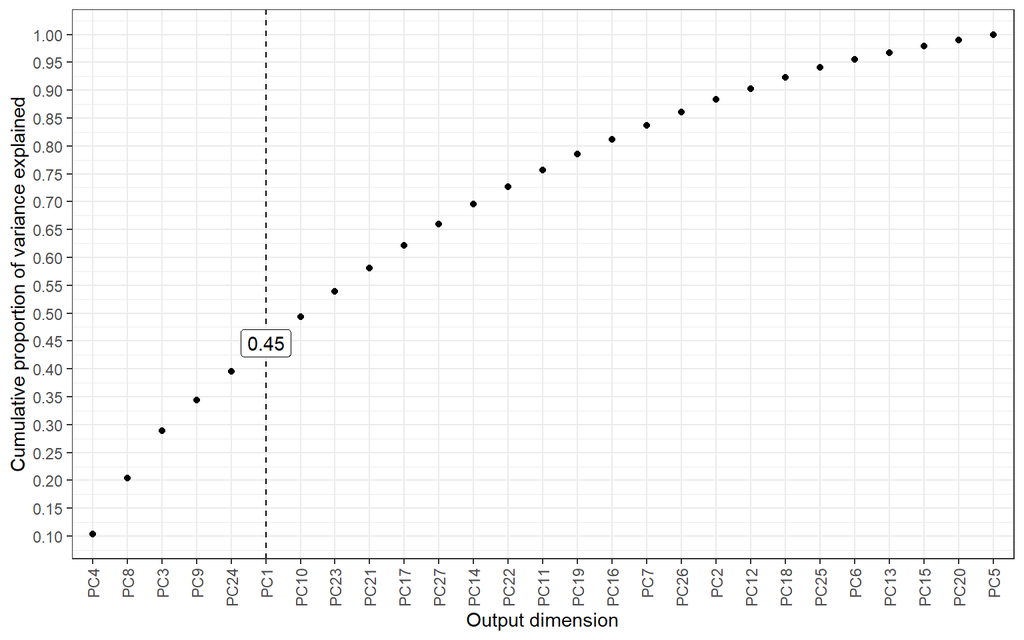

Figure 1: Variance explained

Before visualizing the composition of each PC, one can sort both input (Figure 2) and output dimensions (Figure 3). This is done using hierarchical clustering over all instances in training set. Here below one can find the codes to do so.

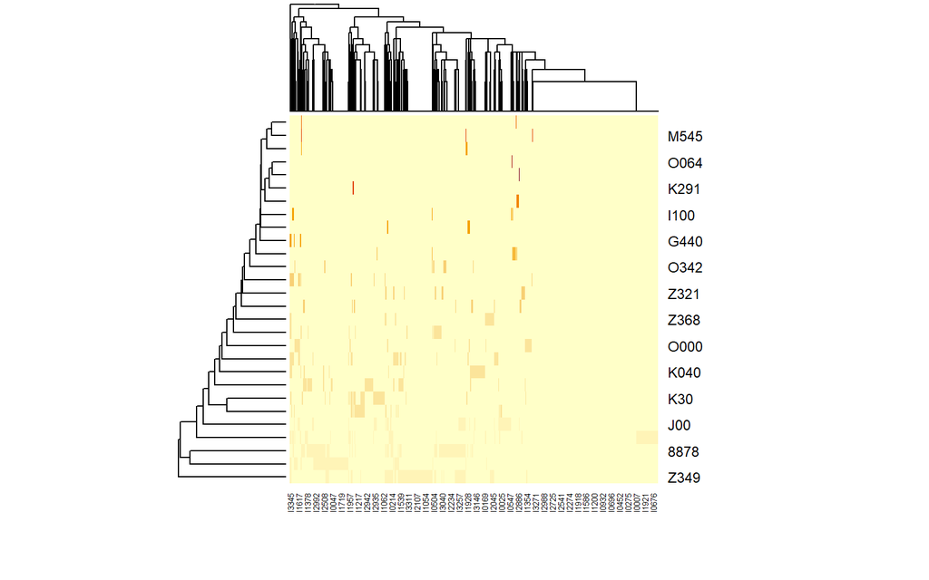

Figure 2: Cluster of input dimensions

```r
input_dim_order=
  colnames(input_train)[heatmap(t(input_train))$rowInd]
```

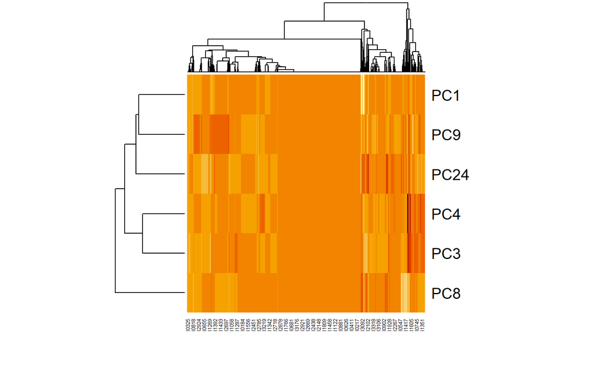

Figure 3: Cluster of output dimensions

```r
output_dim_order=
  rownames(dr_bin_nps_train)[heatmap(exprs(dr_bin_nps_train))$rowInd]
```

Since both input and output dimensions using codes, we may want to describe about each of them. We use description for ICD-10 codes. Meanwhile, the PCs is described by interpreting the input dimensions that have higher weights as absolute values, as shown by the codes below.

```r
input_dim_desc=
  mh_bin_nps_train %>%
  fData() %>%
  rename(input_dim_desc=desc) %>%
  rbind(
    data.frame(
      input_dim_desc='Preeclampsia/eclampsia'
      ,row.names='outcome'
    )
  ) %>%
  .[input_dim_order,,drop=F] %>%
  rownames_to_column(var='input_dim')

output_dim_desc=
  c('PC8','Problems with previous pregnancy'
    ,'PC3','Lacking/late antenatal screening'
    ,'PC4','Commond cold with lab check'
    ,'PC24','Various problems increasing visits'
    ,'PC9','High-risk pregnancy'
    ,'PC1','Unknown') %>%
  matrix(ncol=2,byrow=T) %>%
  data.frame(output_dim=.[,1],output_dim_desc=.[,2])
```

RSDR object has a specific method for plotting (Figure 4). This plot() function can incorporate vectors to sort the dimensions and data frames to describe them. A non-negative cutoff of 0.01 can be optionally set to remove all input dimensions having weights as absolute values equal or below this cutoff.

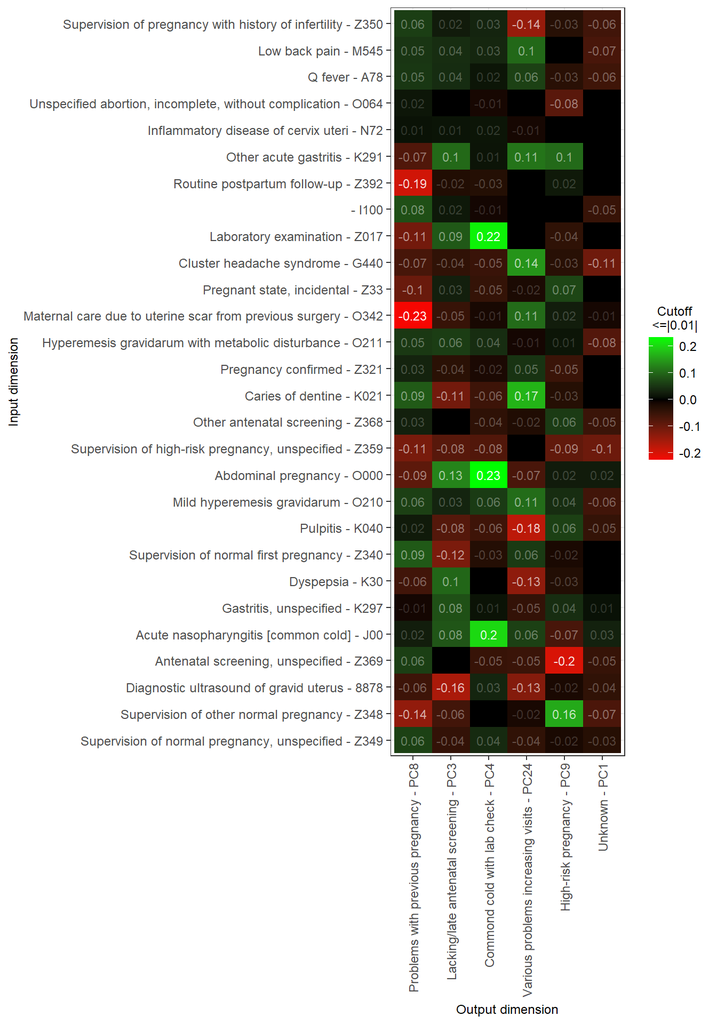

Figure 4: Dimension transformer

```r
rsdr_bin_nps_train %>%
  plot(
    w_cutoff=0.01
    ,label=T
    ,input_dim_order=input_dim_order
    ,output_dim_order=output_dim_order
    ,input_dim_desc=input_dim_desc
    ,output_dim_desc=output_dim_desc
  )
```

# 4 Predictive performance

We develop this package with motivation for predictive modeling. We can compare whether a dimensional reduction method, i.e. PCA, can help to improve predictive performance, compared to that without applying the method. Both groups use medical histories with no perfect separation and binary transformation. Using only training set, we apply 30-times bootstrapping.

```r
set.seed(66)
int_val=
  trainControl(
    method='boot'
    ,number=30
    ,savePredictions=T
    ,classProbs=T
    ,summaryFunction=twoClassSummary
    ,allowParallel=F
  )
```

Logistic regression models are developed using training set with or without transformation into PCs. To prevent overfitting and develop comparable models, feature candidates are randomized into only 6 variables for a model without PCs. Parameter tuning is conducted by random search of 10 tuning parameters. Area under the receiver operating characteristics (AUROC) is applied to evaluate the predictive performances.

```r
set.seed(66)
rand_predictor_candidates=sample(rownames(mh_bin_nps_train),6,F)
mod_mh_bin_nps=
  suppressWarnings(train(
    outcome~.
    ,data=
      mh_bin_nps_train %>%
      exprs() %>%
      t() %>%
      as.data.frame() %>%
      select_at(rand_predictor_candidates) %>%
      cbind(data.frame(outcome=mh_bin_nps_train$outcome))
    ,method='glm'
    ,metric='ROC'
    ,trControl=int_val
    ,tuneLength=10
  ))

set.seed(66)
mod_dr_bin_nps=
  suppressWarnings(train(
    outcome~.
    ,data=
      dr_bin_nps_train %>%
      exprs() %>%
      t() %>%
      as.data.frame() %>%
      cbind(data.frame(outcome=dr_bin_nps_train$outcome))
    ,method='glm'
    ,metric='ROC'
    ,trControl=int_val
    ,tuneLength=10
  ))
```

After training, we evaluate the models using the testing set. An interval estimate by 95% confidence interval (CI) is computed for AUROC of each model. This estimates the generalizability of the model predictive performances.

```r
eval_mh_bin_nps=
  mod_mh_bin_nps %>%
  predict(
    newdata=
      mh_bin_nps_test %>%
      exprs() %>%
      t() %>%
      as.data.frame() %>%
      cbind(data.frame(outcome=mh_bin_nps_test$outcome))
    ,type='prob'
  ) %>%
  cbind(data.frame(obs=mh_bin_nps_test$outcome)) %>%
  evalm(showplots=F,silent=T) %>%
  .$optres %>%
  .$Group1 %>%
  .['AUC-ROC',]

eval_dr_bin_nps=
  mod_dr_bin_nps %>%
  predict(
    newdata=
      dr_bin_nps_test %>%
      exprs() %>%
      t() %>%
      as.data.frame() %>%
      cbind(data.frame(outcome=dr_bin_nps_test$outcome))
    ,type='prob'
  ) %>%
  cbind(data.frame(obs=dr_bin_nps_test$outcome)) %>%
  evalm(showplots=F,silent=T) %>%
  .$optres %>%
  .$Group1 %>%
  .['AUC-ROC',]
```

We can see that applying RSDR (i.e. 10-fold cross-validated PCA) can improve the predictive performance (Table 2). Of course, this may apply for this dataset but not for others. Comparison is needed for every development of a prediction model. Yet, RSDR can enlarge hypothesis space to optimize performance of a prediction model. In addition, RSDR allows us to follow EPV eligibility, especially if our sample size is quite small. Otherwise, we may find overfitting that is not always feasible to evaluate using a validation technique.

Table 2: Predictive performance using different feature representation.

| Applying re-sampled dimensional reduction (RSDR)? | AUROC | CI |
| --- | --- | --- |
| No | 0.59 | 0.48-0.7 |
| Yes | 0.69 | 0.58-0.8 |